# Spatial Analysis of Best Models

# 1. Load Data on Model Results for all Country

Loading the *csv* to R enivronment:

```r
library(readr)
HMD_BestResults <- read_csv("HMD_BestResultsByCountry_Rotated+GAM+NN.csv")
HMD_BestResults <- as.data.frame(HMD_BestResults)
str(HMD_BestResults)
```

```
'data.frame':   38 obs. of  13 variables:
 $ Country                            : chr  "AUS" "AUT" "BEL" "BGR" ...
```

[output not shown]

```
 $ min_mse_female_validation_RotatedLC: num  0.0193 0.0457 0.0403 0.0494 0.0783 ...
 $ min_mse_male_validation_RotatedLC  : num  0.0382 0.0269 0.0284 0.0944 0.0954 ...
 $ mse_male_test_RotatedLC            : num  0.1083 0.0985 0.0888 0.2671 0.3016 ...
 $ mse_female_test_RotatedLC          : num  0.0425 0.0822 0.0778 0.095 0.2431 ...
 $ min_mse_female_validation_LCwithGAM: num  0.0214 0.0487 0.0404 0.0482 0.0439 ...
 $ min_mse_male_validation_LCwithGAM  : num  0.019 0.0268 0.024 0.0302 0.0514 ...
 $ mse_male_test_LCwithGAM            : num  0.1643 0.1055 0.0895 0.0963 0.2638 ...
 $ mse_female_test_LCwithGAM          : num  0.0603 0.1055 0.1101 0.1087 0.16 ...
 $ mse_male_test_NN_non_boost         : num  0.0254 0.0584 0.0439 0.0501 0.0616 ...
 $ mse_female_test_NN_non_boost       : num  0.0556 0.0603 0.0362 0.0611 0.0546 ...
 $ mse_male_test_NN_boost             : num  0.0247 0.0569 0.0432 0.0429 0.0561 ...
 $ mse_female_test_NN_boost           : num  0.0503 0.0581 0.0345 0.0503 0.0543 ...
```

Remove columns of valdiation results:

```r
HMD_BestResults$min_mse_female_validation_RotatedLC <- NULL
HMD_BestResults$min_mse_male_validation_RotatedLC <- NULL
HMD_BestResults$min_mse_female_validation_LCwithGAM <- NULL
HMD_BestResults$min_mse_male_validation_LCwithGAM <- NULL
str(HMD_BestResults)
```

```
'data.frame':   38 obs. of  9 variables:
 $ Country                     : chr  "AUS" "AUT" "BEL" "BGR" ...
 $ mse_male_test_RotatedLC     : num  0.1083 0.0985 0.0888 0.2671 0.3016 ...
 $ mse_female_test_RotatedLC   : num  0.0425 0.0822 0.0778 0.095 0.2431 ...
 $ mse_male_test_LCwithGAM     : num  0.1643 0.1055 0.0895 0.0963 0.2638 ...
 $ mse_female_test_LCwithGAM   : num  0.0603 0.1055 0.1101 0.1087 0.16 ...
 $ mse_male_test_NN_non_boost  : num  0.0254 0.0584 0.0439 0.0501 0.0616 ...
 $ mse_female_test_NN_non_boost: num  0.0556 0.0603 0.0362 0.0611 0.0546 ...
 $ mse_male_test_NN_boost      : num  0.0247 0.0569 0.0432 0.0429 0.0561 ...
 $ mse_female_test_NN_boost    : num  0.0503 0.0581 0.0345 0.0503 0.0543 ...
```

# 2. Get Best Models and Generate New Variables

Load packages for analysis:

```r
library(ggplot2)
library(tidyr)
library(dplyr)
```

Get best model for females:

```r
HMD_BestResults$BestFemaleMSE <- apply(HMD_BestResults[,c(3,5,7,9)], 1, FUN = min)


HMD_BestResults$BestFemaleModel <- NA
for (i in 1:nrow(HMD_BestResults)) {
  HMD_BestResults$BestFemaleModel[i] <- names(HMD_BestResults[,1:9])[which(
    HMD_BestResults[,1:9] == HMD_BestResults$BestFemaleMSE[i],
    arr.ind=T)[, "col"]]
}

HMD_BestResults$BestFemaleModel <- stringr::str_remove(HMD_BestResults$BestFemaleModel, "mse_female_test_")

str(HMD_BestResults)
```

```
'data.frame':   38 obs. of  11 variables:
 $ Country                     : chr  "AUS" "AUT" "BEL" "BGR" ...
 $ mse_male_test_RotatedLC     : num  0.1083 0.0985 0.0888 0.2671 0.3016 ...
 $ mse_female_test_RotatedLC   : num  0.0425 0.0822 0.0778 0.095 0.2431 ...
 $ mse_male_test_LCwithGAM     : num  0.1643 0.1055 0.0895 0.0963 0.2638 ...
 $ mse_female_test_LCwithGAM   : num  0.0603 0.1055 0.1101 0.1087 0.16 ...
 $ mse_male_test_NN_non_boost  : num  0.0254 0.0584 0.0439 0.0501 0.0616 ...
 $ mse_female_test_NN_non_boost: num  0.0556 0.0603 0.0362 0.0611 0.0546 ...
 $ mse_male_test_NN_boost      : num  0.0247 0.0569 0.0432 0.0429 0.0561 ...
 $ mse_female_test_NN_boost    : num  0.0503 0.0581 0.0345 0.0503 0.0543 ...
 $ BestFemaleMSE               : num  0.0425 0.0581 0.0345 0.0503 0.0543 ...
 $ BestFemaleModel             : chr  "RotatedLC" "NN_boost" "NN_boost" "NN_boost" ...
```

Get best model for males:

```r
HMD_BestResults$BestMaleMSE <- apply(HMD_BestResults[,c(2,4,6,8)], 1, FUN = min)


HMD_BestResults$BestMaleModel <- NA
for (i in 1:nrow(HMD_BestResults)) {
  HMD_BestResults$BestMaleModel[i] <- names(HMD_BestResults[,1:9])[which(
    HMD_BestResults[,1:9] == HMD_BestResults$BestMaleMSE[i],
    arr.ind=T)[, "col"]]
}

HMD_BestResults$BestMaleModel <- stringr::str_remove(HMD_BestResults$BestMaleModel, "mse_male_test_")

str(HMD_BestResults)
```

```
'data.frame':   38 obs. of  13 variables:
 $ Country                     : chr  "AUS" "AUT" "BEL" "BGR" ...
 $ mse_male_test_RotatedLC     : num  0.1083 0.0985 0.0888 0.2671 0.3016 ...
 $ mse_female_test_RotatedLC   : num  0.0425 0.0822 0.0778 0.095 0.2431 ...
 $ mse_male_test_LCwithGAM     : num  0.1643 0.1055 0.0895 0.0963 0.2638 ...
 $ mse_female_test_LCwithGAM   : num  0.0603 0.1055 0.1101 0.1087 0.16 ...
 $ mse_male_test_NN_non_boost  : num  0.0254 0.0584 0.0439 0.0501 0.0616 ...
 $ mse_female_test_NN_non_boost: num  0.0556 0.0603 0.0362 0.0611 0.0546 ...
 $ mse_male_test_NN_boost      : num  0.0247 0.0569 0.0432 0.0429 0.0561 ...
 $ mse_female_test_NN_boost    : num  0.0503 0.0581 0.0345 0.0503 0.0543 ...
 $ BestFemaleMSE               : num  0.0425 0.0581 0.0345 0.0503 0.0543 ...
 $ BestFemaleModel             : chr  "RotatedLC" "NN_boost" "NN_boost" "NN_boost" ...
 $ BestMaleMSE                 : num  0.0247 0.0569 0.0432 0.0429 0.0561 ...
 $ BestMaleModel               : chr  "NN_boost" "NN_boost" "NN_boost" "NN_boost" ...
```

See the best model frequencies:

```r
table(HMD_BestResults$BestFemaleModel)
```

```
    NN_boost NN_non_boost    RotatedLC
          21           14            3
```

```r
table(HMD_BestResults$BestMaleModel)
```

```
    NN_boost NN_non_boost
          28           10
```

Looks like *NN_boost* really dominates and only the *NN_non_boost* won in more than $3$ countries.

Let’s check the *NN_boost* advantage to the *NN_non_boost* solution in each country for both genders:

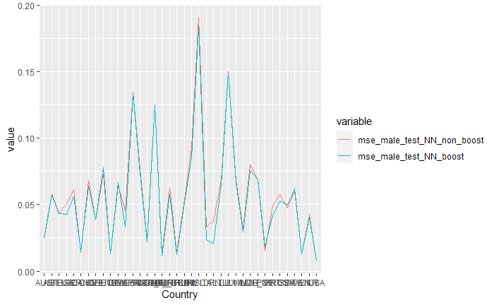

```r
temp_df <- reshape2::melt(HMD_BestResults[,c("Country", "mse_male_test_NN_non_boost", "mse_male_test_NN_boost")],
                            id.var = "Country")

ggplot(temp_df, aes(x = Country, y = value, color = variable, group=variable)) +
  geom_line()
```

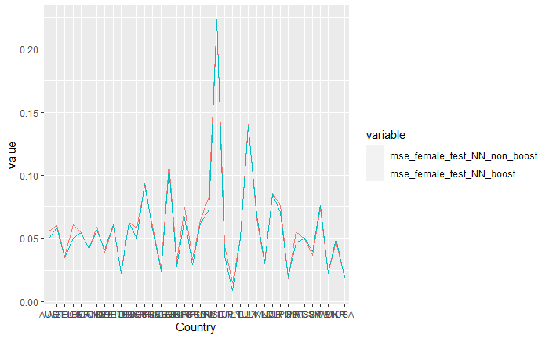

```r
temp_df <- reshape2::melt(HMD_BestResults[,c("Country", "mse_female_test_NN_non_boost", "mse_female_test_NN_boost")],
                            id.var = "Country")

ggplot(temp_df, aes(x = Country, y = value, color = variable, group=variable)) +
  geom_line()
```

It seems that the MSE of *NN_boost* and *NN_non_boost* do not differ ignificantly when the *NN_non_boost* is in the lead.

So, next we generate a variable that measures the *NN_boost* advantage in $MSE$ compared to the best **not NN** model.

```r
HMD_BestResults$BestMaleMSE_notNN <- apply(HMD_BestResults[,c(2,4)], 1, FUN = min)
HMD_BestResults$NN_boost_vs_Best_notNN_male <- HMD_BestResults$mse_male_test_NN_boost - HMD_BestResults$BestMaleMSE_notNN

HMD_BestResults$BestFemaleMSE_notNN <- apply(HMD_BestResults[,c(3,5)], 1, FUN = min)
HMD_BestResults$NN_boost_vs_Best_notNN_female <- HMD_BestResults$mse_female_test_NN_boost - HMD_BestResults$BestFemaleMSE_notNN

str(HMD_BestResults)
```

```
'data.frame':   38 obs. of  17 variables:
 $ Country                      : chr  "AUS" "AUT" "BEL" "BGR" ...
 $ mse_male_test_RotatedLC      : num  0.1083 0.0985 0.0888 0.2671 0.3016 ...
 $ mse_female_test_RotatedLC    : num  0.0425 0.0822 0.0778 0.095 0.2431 ...
 $ mse_male_test_LCwithGAM      : num  0.1643 0.1055 0.0895 0.0963 0.2638 ...
 $ mse_female_test_LCwithGAM    : num  0.0603 0.1055 0.1101 0.1087 0.16 ...
 $ mse_male_test_NN_non_boost   : num  0.0254 0.0584 0.0439 0.0501 0.0616 ...
 $ mse_female_test_NN_non_boost : num  0.0556 0.0603 0.0362 0.0611 0.0546 ...
 $ mse_male_test_NN_boost       : num  0.0247 0.0569 0.0432 0.0429 0.0561 ...
 $ mse_female_test_NN_boost     : num  0.0503 0.0581 0.0345 0.0503 0.0543 ...
 $ BestFemaleMSE                : num  0.0425 0.0581 0.0345 0.0503 0.0543 ...
 $ BestFemaleModel              : chr  "RotatedLC" "NN_boost" "NN_boost" "NN_boost" ...
 $ BestMaleMSE                  : num  0.0247 0.0569 0.0432 0.0429 0.0561 ...
 $ BestMaleModel                : chr  "NN_boost" "NN_boost" "NN_boost" "NN_boost" ...
 $ BestMaleMSE_notNN            : num  0.1083 0.0985 0.0888 0.0963 0.2638 ...
 $ NN_boost_vs_Best_notNN_male  : num  -0.0836 -0.0416 -0.0456 -0.0534 -0.2077 ...
 $ BestFemaleMSE_notNN          : num  0.0425 0.0822 0.0778 0.095 0.16 ...
 $ NN_boost_vs_Best_notNN_female: num  0.00777 -0.02412 -0.04336 -0.04464 -0.10572 ...
```

# 3. Draw Some Maps

See the best models in each country on the world map!

First, download the shapefile:

```r
# Download the shapefile.
download.file("http://thematicmapping.org/downloads/TM_WORLD_BORDERS_SIMPL-0.3.zip" , destfile="GeoData/world_shape_file.zip")
# Unzip the file.
system("unzip GeoData/world_shape_file.zip")
```

```
[1] 127
```

Load the shapefile to R:

```r
library(rgdal)

# Rread the shape file
world_spdf <- readOGR(
  dsn= paste0(getwd(),"/GeoData") ,
  layer="TM_WORLD_BORDERS_SIMPL-0.3",
  verbose=FALSE
)

# Save the original order of countries so that we don't mess up the shapefile with the merge
world_spdf@data$OriginalOrder <- 1:nrow(world_spdf@data)
```

Cleaning the country codes in the `HMD_BestResults` dataframe:

```r
# Creating the dataframe to join
HMD_ResultsToMap <- HMD_BestResults[,c("Country", "BestFemaleModel", "BestMaleModel",
                                       "NN_boost_vs_Best_notNN_male", "NN_boost_vs_Best_notNN_female")]

# Unify some country codes
HMD_ResultsToMap$Country[HMD_ResultsToMap$Country == "FRATNP"] <- "FRA"
HMD_ResultsToMap$Country[HMD_ResultsToMap$Country == "DEUTW"] <- "DEU"
HMD_ResultsToMap$Country[HMD_ResultsToMap$Country == "NZL_NP"] <- "NZL"
HMD_ResultsToMap$Country[HMD_ResultsToMap$Country == "GBR_NP"] <- "GBR"
```

Join with relevant variables from `HMD_ResultsToMap`:

```r
ShapeDataTemp <- merge(x=world_spdf@data, y=HMD_ResultsToMap, by.x="ISO3", by.y="Country", all.x=TRUE)

# Clean up the categorical variables and convert them to factor
ShapeDataTemp$BestMaleModel[is.na(ShapeDataTemp$BestMaleModel)] <- "No_Data"
ShapeDataTemp$BestFemaleModel[is.na(ShapeDataTemp$BestFemaleModel)] <- "No_Data"
ShapeDataTemp$BestFemaleModel <- as.factor(ShapeDataTemp$BestFemaleModel)
ShapeDataTemp$BestMaleModel <- as.factor(ShapeDataTemp$BestMaleModel)

world_spdf@data <- ShapeDataTemp[order(ShapeDataTemp$OriginalOrder),]
```

Draw the map of the best models for **female**s!

```r
library(leaflet)

# Create a color palette for the map
mypalette <- colorFactor(c("green", "blue", "grey", "orange"),
                         world_spdf@data$BestFemaleModel)

# Prepare the text for tooltips
mytext <- paste(
    "Country: ", world_spdf@data$NAME,"<br/>",
    "Best Model Female: ", world_spdf@data$BestFemaleModel, "<br/>",
    "NN_boost_vs_Best_notNN_female: ", round(world_spdf@data$NN_boost_vs_Best_notNN_female, 3),
    sep="") %>%
  lapply(htmltools::HTML)

# Create map object
m <- leaflet(world_spdf) %>%
  addTiles()  %>%
  setView( lat=10, lng=0 , zoom=2) %>%
  addPolygons(
    fillColor = ~mypalette(BestFemaleModel),
    stroke=FALSE,
    label = mytext,
    labelOptions = labelOptions(
      style = list("font-weight" = "normal", padding = "3px 8px"),
      textsize = "13px",
      direction = "auto"
    )
  ) %>%
  addLegend(pal=mypalette, values=~BestFemaleModel, opacity=0.9, title = "Best Model for Females", position = "bottomleft")

# Show map object
m

# Save map in a html file
htmlwidgets::saveWidget(m, file="BestFemaleModel.html")
```

[output not shown]

Draw the map of the best models for **male**s!

```r
library(leaflet)

# Create a color palette for the map
mypalette <- colorFactor(c("green", "blue", "grey"),
                         world_spdf@data$BestMaleModel)

# Prepare the text for tooltips
mytext <- paste(
    "Country: ", world_spdf@data$NAME,"<br/>",
    "Best Model Male: ", world_spdf@data$BestMaleModel, "<br/>",
    "NN_boost_vs_Best_notNN_male: ", round(world_spdf@data$NN_boost_vs_Best_notNN_male, 3),
    sep="") %>%
  lapply(htmltools::HTML)

# Create map object
m <- leaflet(world_spdf) %>%
  addTiles()  %>%
  setView( lat=10, lng=0 , zoom=2) %>%
  addPolygons(
    fillColor = ~mypalette(BestMaleModel),
    stroke=FALSE,
    label = mytext,
    labelOptions = labelOptions(
      style = list("font-weight" = "normal", padding = "3px 8px"),
      textsize = "13px",
      direction = "auto"
    )
  ) %>%
  addLegend(pal=mypalette, values=~BestMaleModel, opacity=0.9, title = "Best Model for Males", position = "bottomleft")

# Show map object
m

# Save map in a html file
htmlwidgets::saveWidget(m, file="BestMaleModel.html")
```

[output not shown]

Draw the map of *NN_boost* advantage in $MSE$ compared to the *best not NN* model for **female**s!

```r
library(leaflet)

# Create a color palette for the map
mypalette <- colorNumeric(palette = "RdYlGn",
                          domain = world_spdf@data$NN_boost_vs_Best_notNN_female,
                          na.color="transparent",
                          reverse = TRUE)

# Prepare the text for tooltips
mytext <- paste(
    "Country: ", world_spdf@data$NAME,"<br/>",
    "Best Model Female: ", world_spdf@data$BestMaleFemodel, "<br/>",
    "NN_boost_vs_Best_notNN_female: ", round(world_spdf@data$NN_boost_vs_Best_notNN_female, 3),
    sep="") %>%
  lapply(htmltools::HTML)

# Create map object
m <- leaflet(world_spdf) %>%
  addTiles()  %>%
  setView( lat=10, lng=0 , zoom=2) %>%
  addPolygons(
    fillColor = ~mypalette(NN_boost_vs_Best_notNN_female),
    stroke=TRUE,
    fillOpacity = 0.9,
    color="white",
    weight=0.3,
    label = mytext,
    labelOptions = labelOptions(
      style = list("font-weight" = "normal", padding = "3px 8px"),
      textsize = "13px",
      direction = "auto"
    )
  ) %>%
  addLegend(pal=mypalette, values=~NN_boost_vs_Best_notNN_female, opacity=0.9, title = "NN_boost advantage in MSE - Female", position = "bottomleft")

# Show map object
m
```

[interactive chart not shown]

```r
# Save map in a html file
htmlwidgets::saveWidget(m, file="NNboostAdvantageFemale.html")
```

Draw the map of *NN_boost* advantage in $MSE$ compared to the *best not NN* model for **male**s!

```r
library(leaflet)

# Create a color palette for the map
mypalette <- colorNumeric(palette = "RdYlGn",
                          domain = world_spdf@data$NN_boost_vs_Best_notNN_male,
                          na.color="transparent",
                          reverse = TRUE)

# Prepare the text for tooltips
mytext <- paste(
    "Country: ", world_spdf@data$NAME,"<br/>",
    "Best Model Male: ", world_spdf@data$BestMaleModel, "<br/>",
    "NN_boost_vs_Best_notNN_male: ", round(world_spdf@data$NN_boost_vs_Best_notNN_male, 3),
    sep="") %>%
  lapply(htmltools::HTML)

# Create map object
m <- leaflet(world_spdf) %>%
  addTiles()  %>%
  setView( lat=10, lng=0 , zoom=2) %>%
  addPolygons(
    fillColor = ~mypalette(NN_boost_vs_Best_notNN_male),
    stroke=TRUE,
    fillOpacity = 0.9,
    color="white",
    weight=0.3,
    label = mytext,
    labelOptions = labelOptions(
      style = list("font-weight" = "normal", padding = "3px 8px"),
      textsize = "13px",
      direction = "auto"
    )
  ) %>%
  addLegend(pal=mypalette, values=~NN_boost_vs_Best_notNN_male, opacity=0.9, title = "NN_boost advantage in MSE - Male", position = "bottomleft")

# Show map object
m

# Save map in a html file
htmlwidgets::saveWidget(m, file="NNboostAdvantageMale.html")
```

[output not shown]

# 4. Examine Correlations between NN_boost Performance and RotatedLC optimal parameters

Get the best *RotatedLC* parameters for each country.

Load the detailed *RotatedLC* results:

```r
load("HMD_RotatedLC_Full_LogMSE.Rda")
str(HMD_RotatedLC_Full)
```

```
'data.frame':   130200 obs. of  7 variables:
 $ p                    : num  0 0 0 0 0 0 0 0 0 0 ...
 $ e0l                  : num  60 61 62 63 64 65 66 67 68 69 ...
 $ mse_male_validation  : num  0.0631 0.0631 0.0631 0.0631 0.0631 ...
 $ mse_female_validation: num  0.0322 0.0322 0.0322 0.0322 0.0322 ...
 $ mse_male_test        : num  0.134 0.134 0.134 0.134 0.134 ...
 $ mse_female_test      : num  0.0666 0.0666 0.0666 0.0666 0.0666 ...
 $ Country              : chr  "AUS" "AUS" "AUS" "AUS" ...
```

Adjust column names to be compatible with HMD_BestResults:

```r
colnames(HMD_RotatedLC_Full)[5:6] <- colnames(HMD_BestResults[2:3])
str(HMD_RotatedLC_Full)
```

```
'data.frame':   130200 obs. of  7 variables:
 $ p                        : num  0 0 0 0 0 0 0 0 0 0 ...
 $ e0l                      : num  60 61 62 63 64 65 66 67 68 69 ...
 $ mse_male_validation      : num  0.0631 0.0631 0.0631 0.0631 0.0631 ...
 $ mse_female_validation    : num  0.0322 0.0322 0.0322 0.0322 0.0322 ...
 $ mse_male_test_RotatedLC  : num  0.134 0.134 0.134 0.134 0.134 ...
 $ mse_female_test_RotatedLC: num  0.0666 0.0666 0.0666 0.0666 0.0666 ...
 $ Country                  : chr  "AUS" "AUS" "AUS" "AUS" ...
```

Let’s get the $e0l$ and $p$ parameters based on the test $MSE$ in the `HMD_BestResults` dataframe:

```r
# Males
HMD_Best_withRotatedLC_Male <- HMD_BestResults[,c("Country", "mse_male_test_RotatedLC",
                                                  "NN_boost_vs_Best_notNN_male")]
HMD_Best_withRotatedLC_Male <- merge(HMD_Best_withRotatedLC_Male,
                                     HMD_RotatedLC_Full[,c("Country",
                                                           "mse_male_test_RotatedLC",
                                                           "e0l",
                                                           "p")],
                                     by=c("Country", "mse_male_test_RotatedLC"))

# Get the number of optima
NumberOfOptima <- HMD_Best_withRotatedLC_Male %>% group_by(Country) %>% summarise(NumberOfOptima=dplyr::n())

# Aggregate multiple optima
HMD_Best_withRotatedLC_Male <- HMD_Best_withRotatedLC_Male %>% group_by(Country) %>% summarise_all(mean)

# Add number of optima to summary
HMD_Best_withRotatedLC_Male <- merge(HMD_Best_withRotatedLC_Male, NumberOfOptima, by="Country")

#----------------------------------------------------------------------------------------------------

# Females
HMD_Best_withRotatedLC_Female <- HMD_BestResults[,c("Country", "mse_female_test_RotatedLC",
                                                  "NN_boost_vs_Best_notNN_female")]
HMD_Best_withRotatedLC_Female <- merge(HMD_Best_withRotatedLC_Female,
                                     HMD_RotatedLC_Full[,c("Country",
                                                           "mse_female_test_RotatedLC",
                                                           "e0l",
                                                           "p")],
                                     by=c("Country", "mse_female_test_RotatedLC"))

# Get the number of optima
NumberOfOptima <- HMD_Best_withRotatedLC_Female %>% group_by(Country) %>% summarise(NumberOfOptima=dplyr::n())

# Aggregate multiple optima
HMD_Best_withRotatedLC_Female <- HMD_Best_withRotatedLC_Female %>% group_by(Country) %>% summarise_all(mean)

# Add number of optima to summary
HMD_Best_withRotatedLC_Female <- merge(HMD_Best_withRotatedLC_Female, NumberOfOptima, by="Country")
```

Check the correlation matrices for both genders between *RotatedLC* optimal parameters and the *NN_boost* advantage in $MSE$:

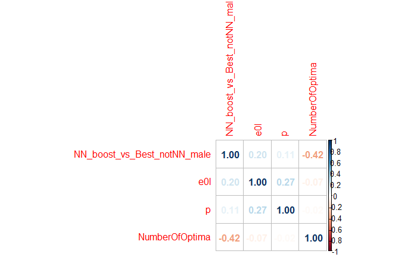

```r
CorrMatrixMales <- cor(HMD_Best_withRotatedLC_Male[,3:ncol(HMD_Best_withRotatedLC_Male)], method = "spearman")
CorrMatrixFemales <- cor(HMD_Best_withRotatedLC_Female[,3:ncol(HMD_Best_withRotatedLC_Female)], method = "spearman")

corrplot::corrplot(CorrMatrixMales, method = "number")
```

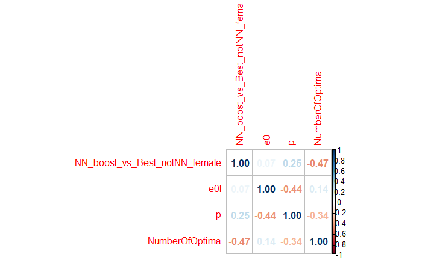

```r
corrplot::corrplot(CorrMatrixFemales, method = "number")
```

We can see that the only significant correlation is a *negative* one between the *Number of Optima* and *NN_boost MSE performance*. So, the **NN_boost has higher MSE (worse perfomance) if the RotatedLC has fewer optimal parameters**. The tendency is **a bit stronger for females than males**.